# Statistical Inference - Course Project - Question 2

2014-09-21

### Synopsis

In this report, I will review and analyze the ToothGrowth data in the R datasets package. This dataset details The Effect of Vitamin C on Tooth Growth in Guinea Pigs. The response is the length of odontoblasts (teeth) in each of 10 guinea pigs at each of three dose levels of Vitamin C (0.5, 1, and 2 mg) with each of two delivery methods (orange juice or ascorbic acid). The Data Dictionary is as follow:

| Field | Data Type | Definition |
| --- | --- | --- |
| `len` | numeric | Tooth length |
| `supp` | factor | Supplement type (OJ or VC). |
| `dose` | numeric | Dose in milligrams. |

### 1 & 2. Load the ToothGrowth data and perform some basic exploratory data analyses. Provide a basic summary of the data.

We call `data(ToothGrowth)` to load the data set and the use `nrow(ToothGrowth)` and find that we a working with 60 rows. Using the `summary(ToothGrowth)` function we get the following basic summary of the data and lastly we use comparitive box plots to get a feel for the relationship between `len`, `supp` and `dose`.

```
##       len       supp         dose
##  Min.   : 4.2   OJ:30   Min.   :0.50
##  1st Qu.:13.1   VC:30   1st Qu.:0.50
##  Median :19.2           Median :1.00
##  Mean   :18.8           Mean   :1.17
##  3rd Qu.:25.3           3rd Qu.:2.00
##  Max.   :33.9           Max.   :2.00
```

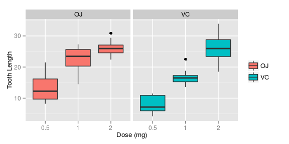

### 3. Use Confidence Intervals (CI) and hypothesis tests to compare tooth growth by supp and dose.

A review of the plot above seems to show that supplement type OJ (orange juice) achieves better growth at lower doses (0.5mg and 1.0mg) than VC (ascorbic acid) but at higher doses they realize comparable growth. It also seems clear dose and growth are positively correlated. Using a Welch Two Sample t-test we can review tooth growth attributed to supplement and dose by calling.

```r
ci <- rbind(
  c('Supplement', t.test(len~supp, data=ToothGrowth[,])$conf),
  c('Dose 0.5mg', t.test(len~supp, data=ToothGrowth[ToothGrowth$dose==0.5,])$conf),
  c('Dose 1.0mg', t.test(len~supp, data=ToothGrowth[ToothGrowth$dose==1.0,])$conf),
  c('Dose 2.0mg', t.test(len~supp, data=ToothGrowth[ToothGrowth$dose==2.0,])$conf)
)
```

| Confidence Interval (CI) | Lower Bound | Upper Bound |
| --- | --- | --- |
| Supplement | -0.171 | 7.571 |
| Dose 0.5mg | 1.719 | 8.781 |
| Dose 1.0mg | 2.802 | 9.058 |
| Dose 2.0mg | -3.798 | 3.638 |